# EDA PROJECT

# Step 20: Relation between effeciency and Horsepower of vehicle across vehicle types

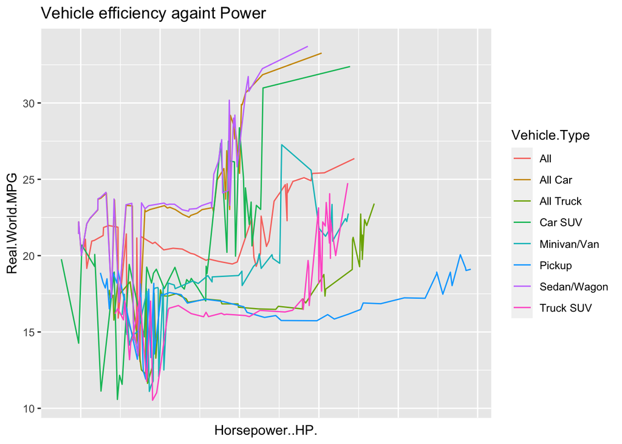

```r
ggplot(rawdata, aes(x=Horsepower..HP., y = Real.World.MPG, group=Vehicle.Type, fill=Vehicle.Type, color=Vehicle.Type)) + stat_summary(fun = sum, na.rm=TRUE, geom='line')+ ggtitle('Vehicle efficiency againt Power')+theme(axis.text.x=element_blank(),axis.ticks.x=element_blank())
```

# Step 21 : Efficiency and vehicle weight relationships, according to vehicle types

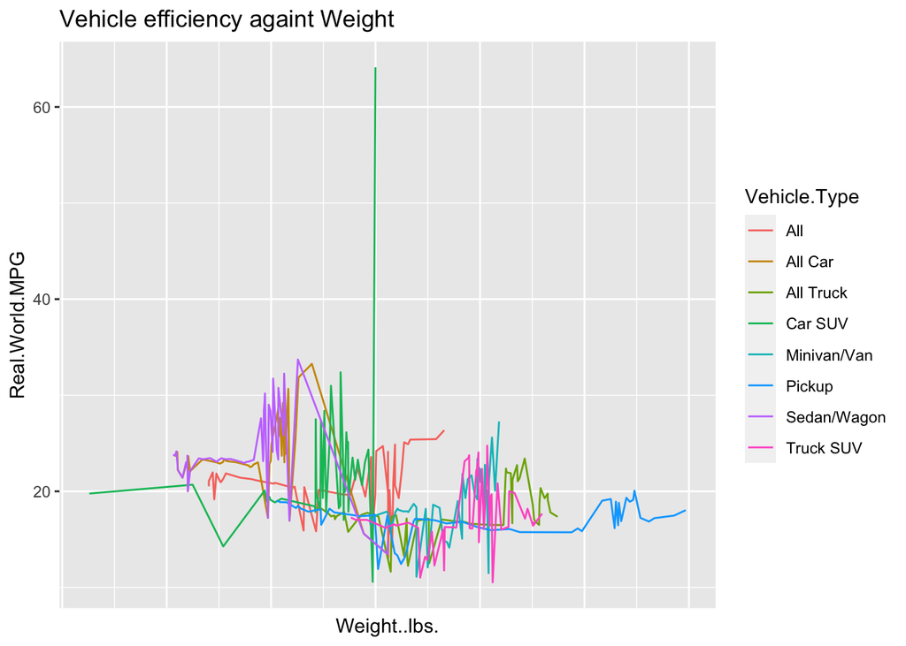

```r
ggplot(rawdata, aes(x=Weight..lbs., y = Real.World.MPG, group=Vehicle.Type, fill=Vehicle.Type, color=Vehicle.Type)) + stat_summary(fun = sum, na.rm=TRUE, geom='line')+ ggtitle('Vehicle efficiency againt Weight')+theme(axis.text.x=element_blank(),axis.ticks.x=element_blank())
```

# Step 22 :Plots are used to visualize the relationships between the variables.

# Need to plot a histogram

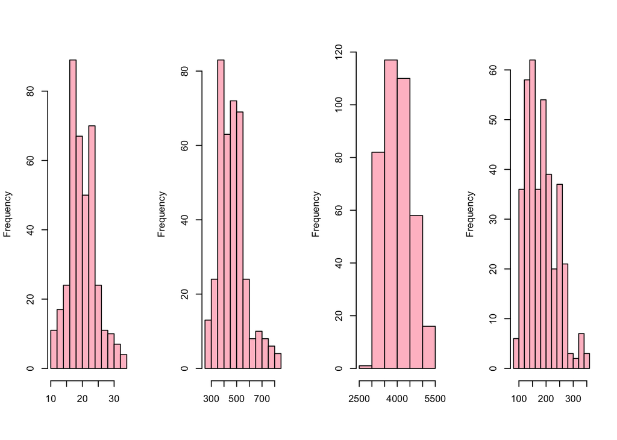

```r
dataframe <- data.frame(
  MPG = rawdata$Real.World.MPG,
  CO2 = rawdata$Real.World.CO2..g.mi.,
  W = rawdata$Weight..lbs.,
  HP = rawdata$Horsepower..HP.
  )
par(mfrow=c(1,4)) # Need to set up a 1x4 grid of plots
for(i in 1:ncol(dataframe)) {
  hist(dataframe[,i], main=colnames(df)[i], xlab="", col="pink")
}
```

Output : Almost all of the variables follow a normal distribution. Both MPG and CO2 have a right-skewed distribution.

# .Step 23: Plotting the effectiveness of distinct vehicle classes is needed

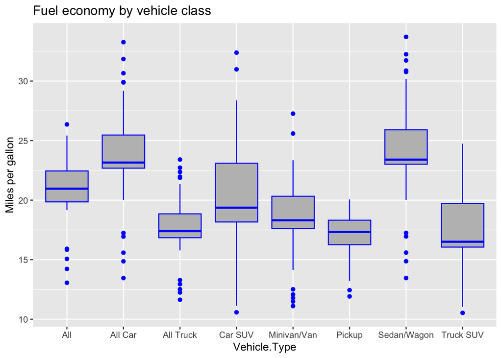

```r
ggplot(rawdata, aes(x=Vehicle.Type, y=Real.World.MPG)) +
  geom_boxplot(fill="grey", color="blue") +
  ggtitle("Fuel economy by vehicle class") +
  ylab("Miles per gallon")
```

Output : The plots show an average fuel economy of 21 MPG across all vehicle categories, and it is clear that sedans have higher fuel efficiency than vehicles, SUVs, and trucks, which have the lowest efficiency.

# Step 24: Vehicle effectiveness over time

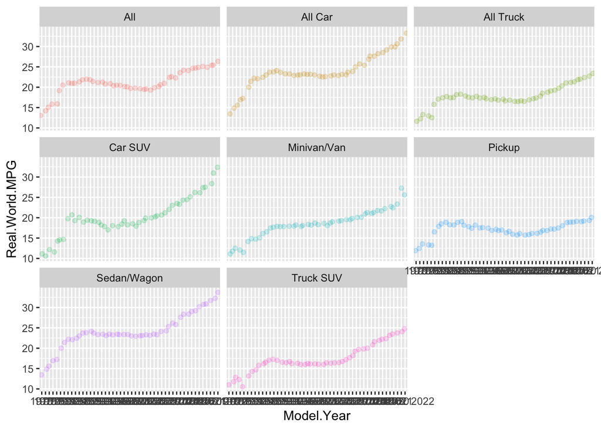

```r
ggplot(data =  rawdata) + geom_point(mapping = aes(x=Model.Year, y = Real.World.MPG, color = Vehicle.Type), position = "jitter", alpha = 0.2, show.legend = FALSE) + facet_wrap(~ Vehicle.Type)
```

Output: Nowadays, all sorts of cars run more effectively, and efficiency is generally on the rise.Furthermore, sedans have continuously had higher MPG over the years when compared to other vehicle classifications.

# Step 25: The relationship between vehicle efficiency and weight needs to be examined and plotted.

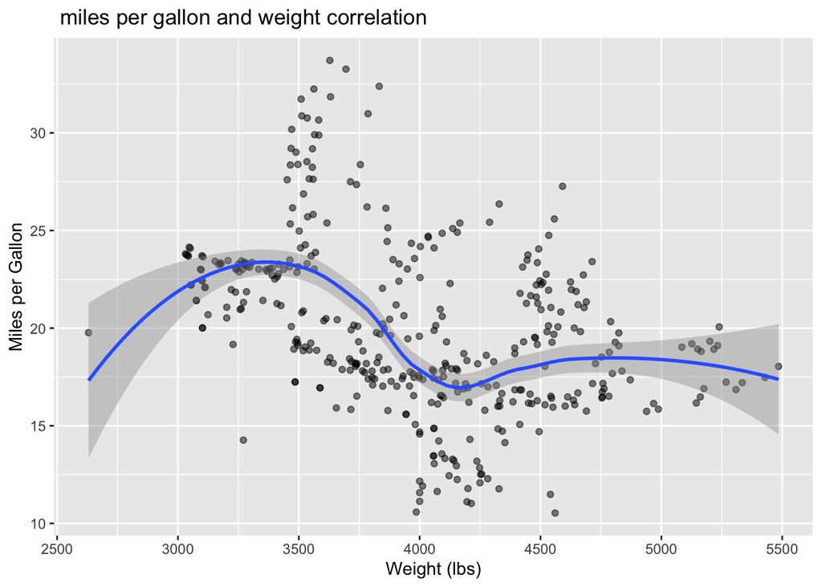

```r
ggplot(data = rawdata) + geom_point(mapping = aes(x=Weight..lbs., y = Real.World.MPG), position = "jitter", alpha = 0.5) + geom_smooth(mapping = aes(x=Weight..lbs., y = Real.World.MPG)) + labs(x = "Weight (lbs)", y = "Miles per Gallon", title = " miles per gallon and weight correlation")
```

Output: According to the Environmental Protection Agency, a car’s fuel economy improves by 1-2% for every 100 pounds eliminated from it. It’s very amazing how the MPG first increased as the vehicle’s weight increased up to 3500 LBS. After this, however, the efficiency dropped as the weight increased as was to be expected.

# Step 26 : over time, the emissions trend

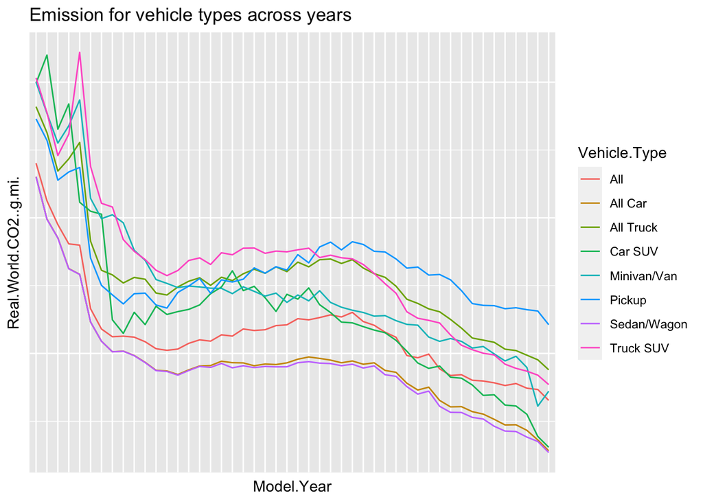

```r
ggplot(rawdata, aes(x=Model.Year, y=Real.World.CO2..g.mi., group=Vehicle.Type, fill=Vehicle.Type, color=Vehicle.Type)) + stat_summary(fun = sum, na.rm=TRUE, geom='line')+ ggtitle('Emission for vehicle types across years')+theme(axis.text.x=element_blank(),axis.ticks.x=element_blank()) +theme(axis.text.y=element_blank(),axis.ticks.y=element_blank())
```

Output : Emissions trend over time for all vehicle classes over the years, the emission shows a declining tendency, with sedans and wagons having the lowest levels. This shows that automakers are developing fuel-efficient automobiles that produce less emissions.Moreover,it can be shown through the exploratory data analysis that the vehicle would operate more efficiently with the ideal balance of weight, horsepower, and additional factors like engine conditions and aerodynamics, which are not included in this data set. Choosing a fuel-efficient car is crucial if you want to keep the environment cleaner and reduce pollution.

# Step 27: Relation between effeciency and Horsepower

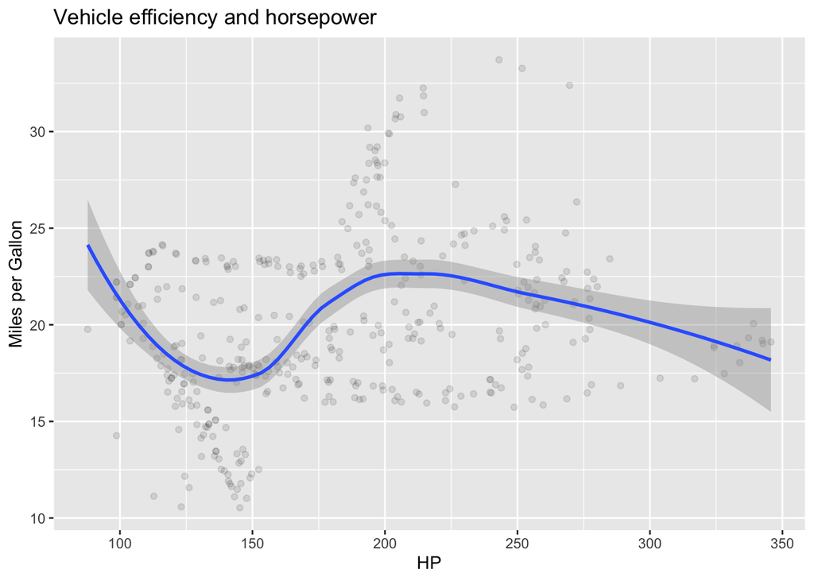

```r
ggplot(data = rawdata) + geom_point(mapping = aes(x=Horsepower..HP., y = Real.World.MPG), position = "jitter", alpha = 0.1) + geom_smooth(mapping = aes(x=Horsepower..HP., y = Real.World.MPG)) + labs(x = "HP", y = "Miles per Gallon", title = "Vehicle efficiency and horsepower")
```

# Step 28: Relation between variables Weight and Horsepower

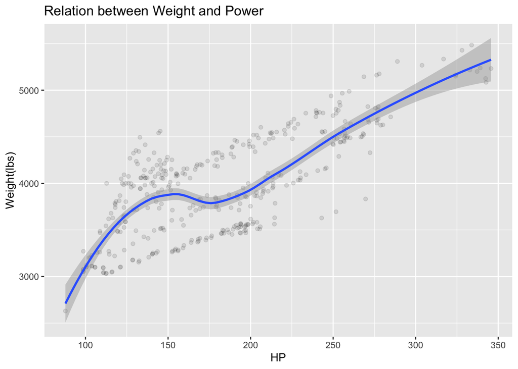

```r
ggplot(data = rawdata) + geom_point(mapping = aes(x=Horsepower..HP., y = Weight..lbs.), position = "jitter", alpha = 0.1) + geom_smooth(mapping = aes(x=Horsepower..HP., y = Weight..lbs.)) + labs(x = "HP", y = "Weight(lbs)", title = "Relation between Weight and Power")
```

Output : The power needed to pull a vehicle directly relates to how much weight it has. The amount of power needed to lift something heavier grows.

# Step 29 : A historical analysis of US car production patterns

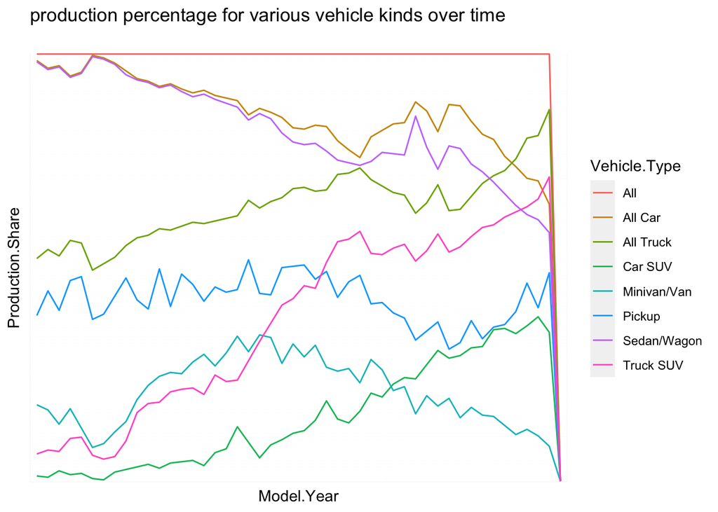

```r
ggplot(rawdata, aes(x=Model.Year, y=Production.Share, group=Vehicle.Type, fill=Vehicle.Type, color=Vehicle.Type)) + stat_summary(fun = sum, na.rm=TRUE, geom='line')+ ggtitle('production percentage for various vehicle kinds over time
')+theme(axis.text.x=element_blank(),axis.ticks.x=element_blank()) +theme(axis.text.y=element_blank(),axis.ticks.y=element_blank())
```

# Step 30 : Relation between MPG and CO2 emission

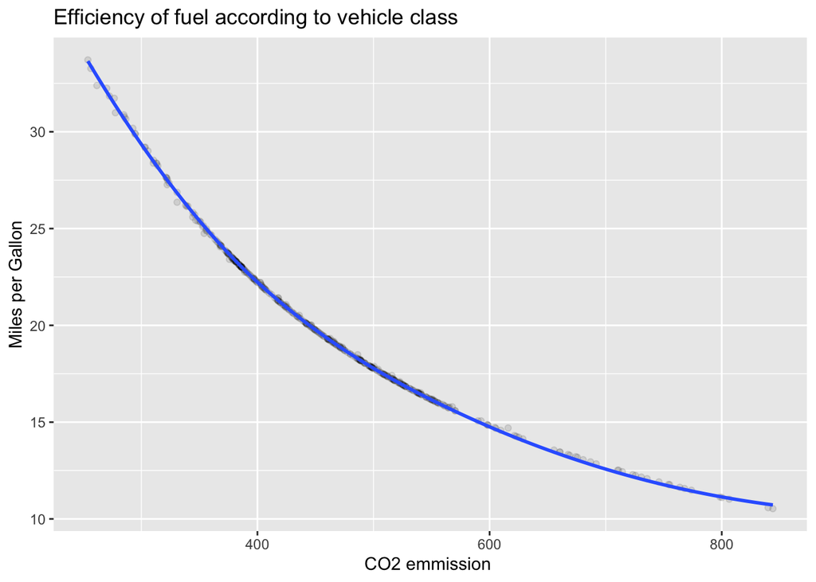

```r
ggplot(data = rawdata) + geom_point(mapping = aes(x=Real.World.CO2..g.mi., y = Real.World.MPG), position = "jitter", alpha = 0.1) + geom_smooth(mapping = aes(x=Real.World.CO2..g.mi., y = Real.World.MPG)) + labs(x = "CO2 emmission ", y = "Miles per Gallon", title = "Efficiency of fuel according to vehicle class")
```

Output : A car with a higher mpg often uses less fuel and emits fewer pollutants, whereas a car with a lower mpg uses more fuel and emits more. They therefore have an inverse relationship.

# Step 31 : Check the correlation

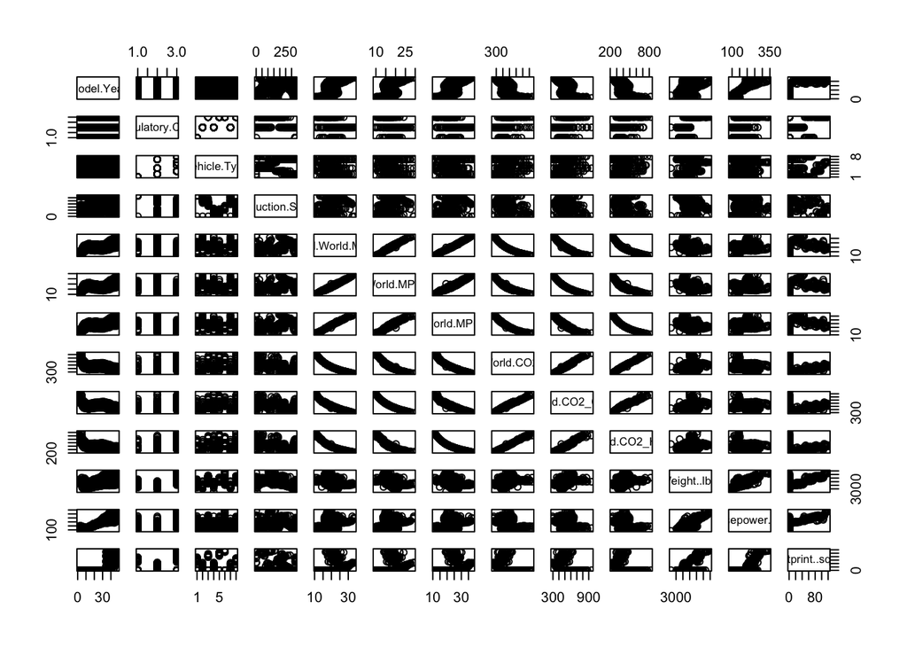

```r
plot(rawdata)
```

# Reference :

Please see the link below for an examination of some of the readings in order to gain a better understanding of the data.

https://www.epa.gov/system/files/documents/2022-12/420s22001.pdf